# Homework 3

Dylan Francisco

July 07, 2023

# Instructions

**Exercises:** 1,3 (Pgs. 90-91); 1 (Pg. 93); 2,4 (Pg. 99); 1,2 (Pg. 101); 2,3,5 (Pg. 104)

**Submission:** Submit via an electronic document on Sakai. Must be submitted as a HTML file generated in RStudio. All assigned problems are chosen according to the textbook *R for Data Science*. You do not need R code to answer every question. If you answer without using R code, delete the code chunk. If the question requires R code, make sure you display R code. If the question requires a figure, make sure you display a figure. A lot of the questions can be answered in written response, but require R code and/or figures for understanding and explaining.

# Chapter 5 (Pgs. 90-91)

## Exercise 1

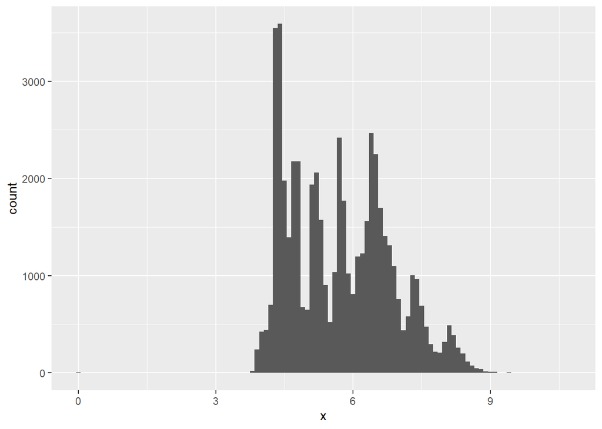

```r
ggplot(diamonds) +
  geom_histogram(mapping = aes(x = x), binwidth = 0.1)
```

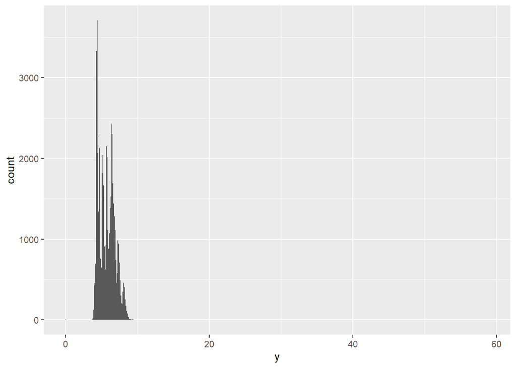

```r
ggplot(diamonds) +
  geom_histogram(mapping = aes(x = y), binwidth = 0.1)
```

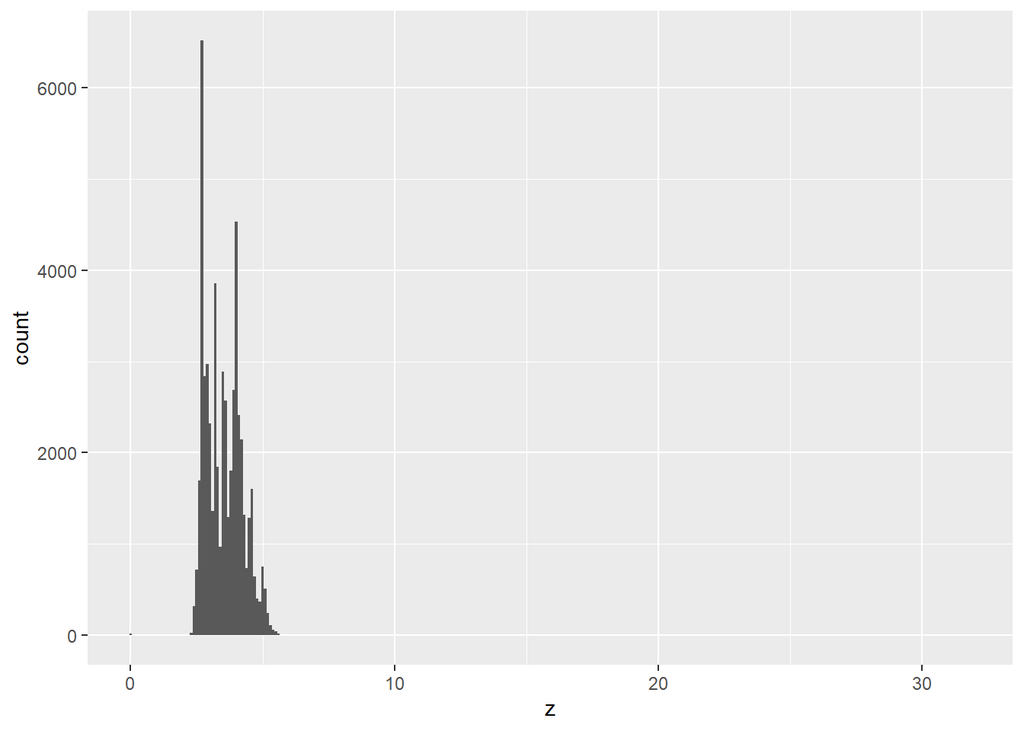

```r
ggplot(diamonds) +
  geom_histogram(mapping = aes(x = z), binwidth = 0.1)
```

## Exercise 3

```r
diamonds.carat99 = filter(diamonds, carat == 0.99)
diamonds.carat1 = filter(diamonds, carat == 1)
count(diamonds.carat99)
```

```
## # A tibble: 1 × 1
##       n
##   <int>
## 1    23
```

```r
count(diamonds.carat1)
```

```
## # A tibble: 1 × 1
##       n
##   <int>
## 1  1558
```

Thee are 23 diamonds with .99 carat and 1558 diamonds with 1 carat. Since there are so few diamond with .99 carat, a potential possibility is that there was errors when shaping the diamonds, causing .01 extra carat shaved off.

# Chapter 5 (Pg. 93)

## Exercise 1

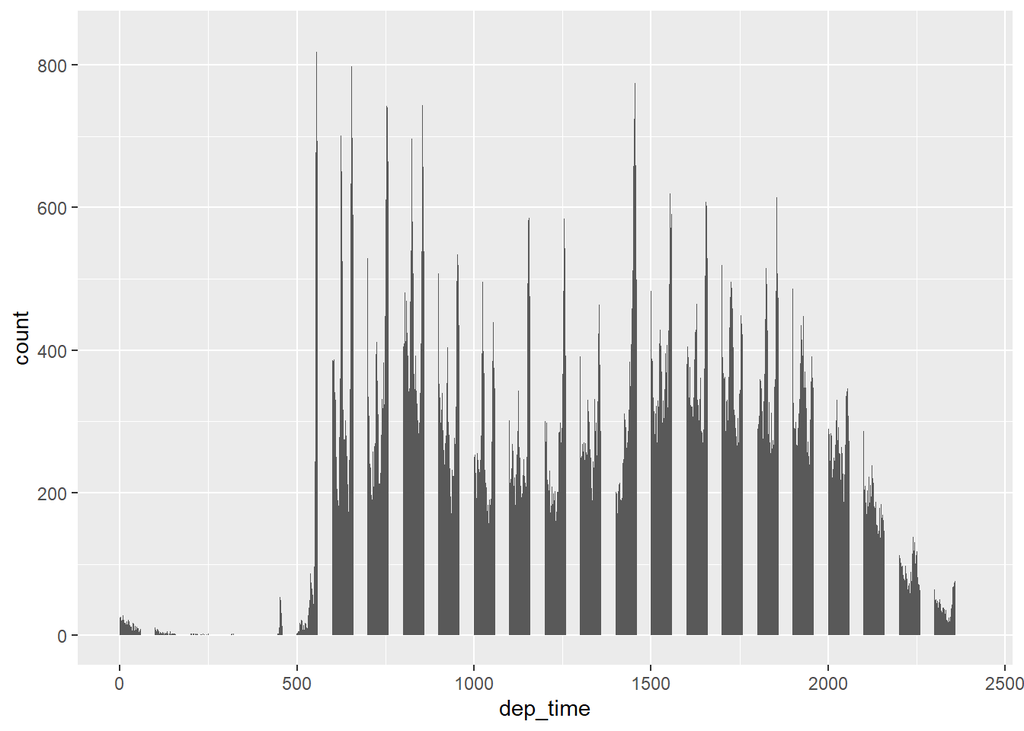

```r
flights <-  nycflights13::flights
ggplot(flights) +
  geom_histogram(mapping = aes(x = dep_time), binwidth = 1)
```

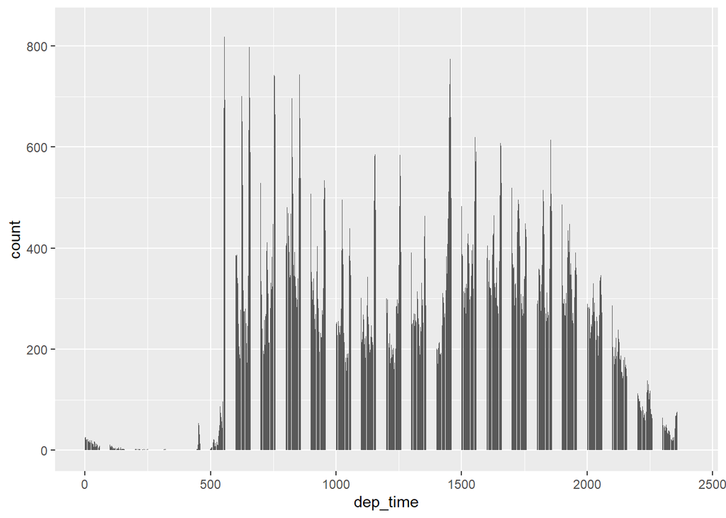

```r
ggplot(flights) +
  geom_bar(mapping = aes(x = dep_time))
```

It seems like both geom_histogram and geom_bar take away the na values when they are plotted. However, geom_bar seems to take more values away because it does not use bins, so those areas are not shaded at all.

# Chapter 5 (Pg. 99)

## Exercise 2

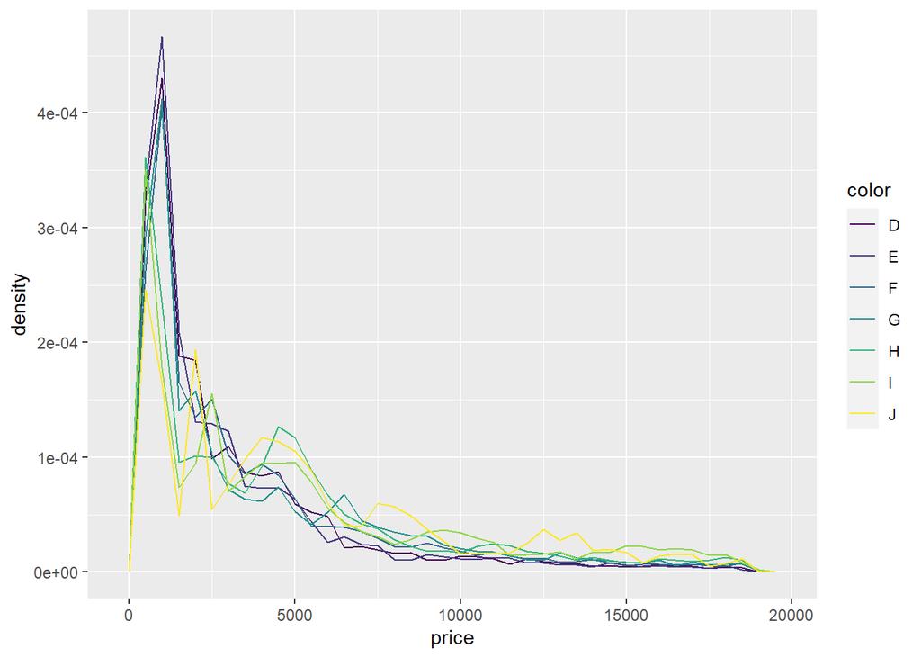

```r
ggplot(
 data = diamonds,
 mapping = aes(x = price, y = ..density..)
 ) +
 geom_freqpoly(mapping = aes(color = color), binwidth = 500)
```

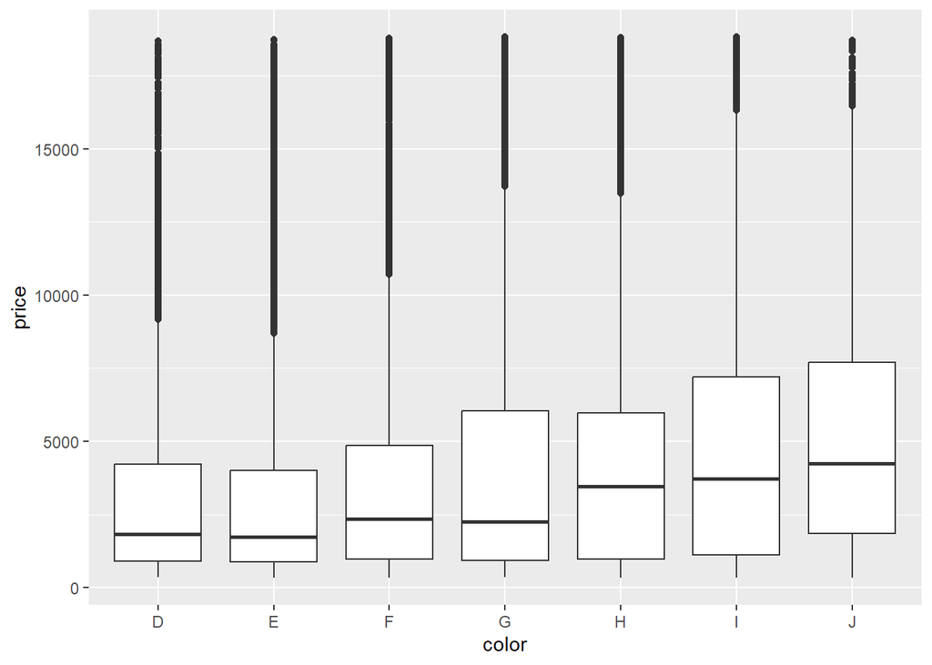

```r
ggplot(data = diamonds, mapping = aes(x = color, y = price)) +
 geom_boxplot()
```

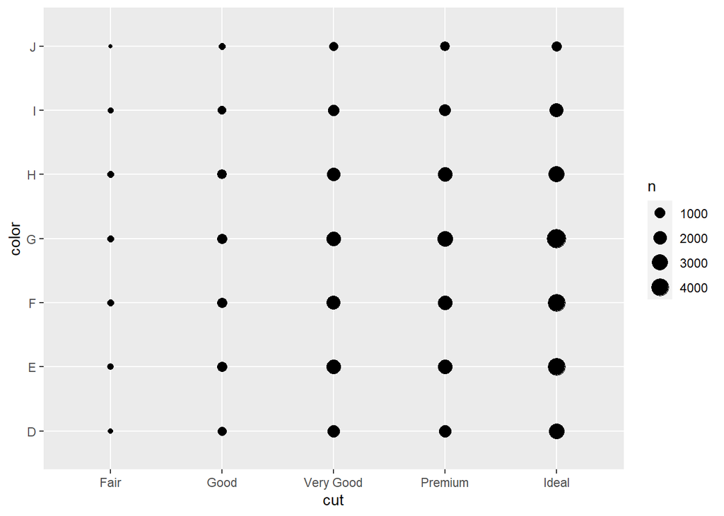

```r
ggplot(data = diamonds, mapping = aes(x = cut, y = color), n=price) +
  geom_count()
```

## Exercise 4

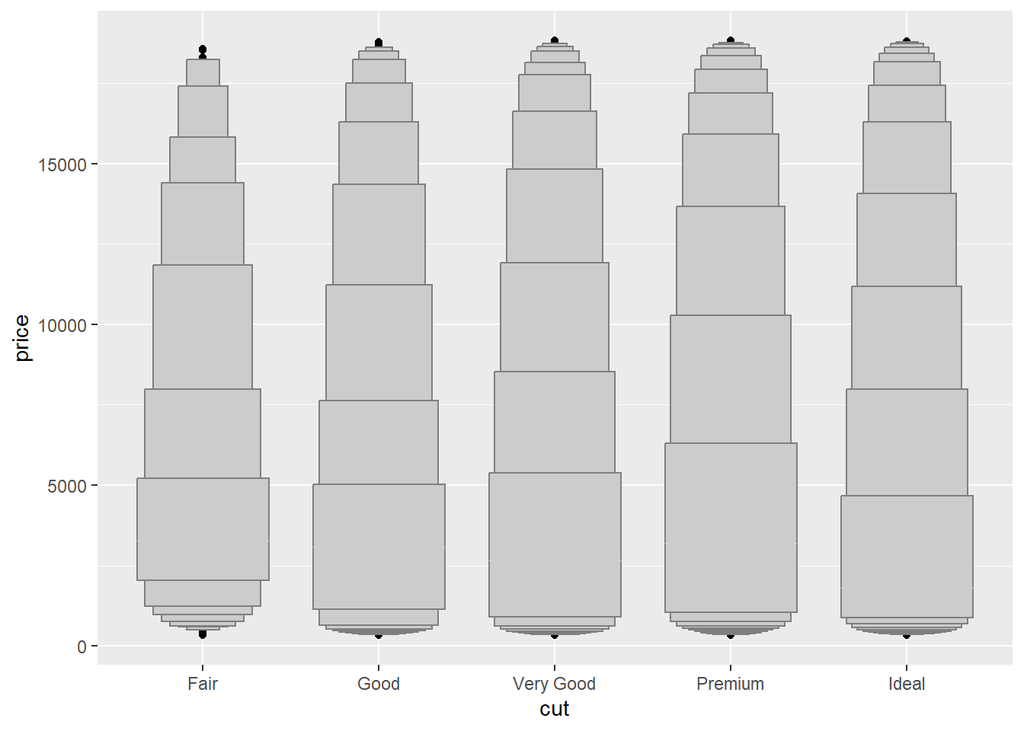

```r
ggplot(data = diamonds, mapping  = aes(x = cut, y = price)) +
  geom_lv()
```

With this data, I learned that most cuts of diamond are relatively similar when it comes to determining the price. Most diamonds are at or below $10,000, and besides the Fair cut, the other cuts have similar prices compared to their cut.

# Chapter 5 (Pg. 101)

## Exercise 1

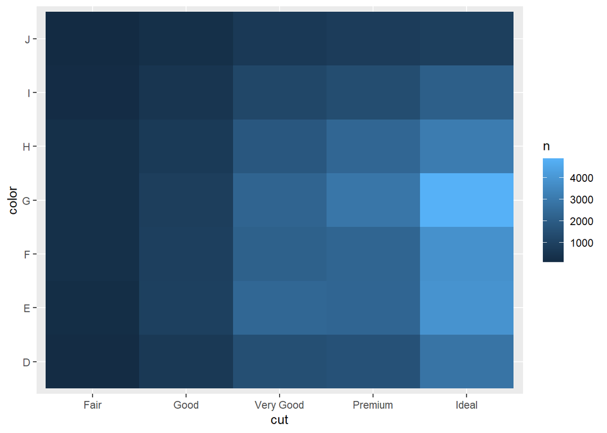

```r
diamonds %>%
 count(color, cut) %>%
 ggplot(mapping = aes(x = cut, y = color)
        )+
 geom_tile(mapping = aes(fill = n))
```

I feel like putting the cut as the x-axis makes the distribution easier to understand and more clear overall. It shows that when getting to the ideal cut, there are more of the higher-tier colors.

## Exercise 2

```r
delay <- flights %>%
  group_by(dest, month) %>%
  summarize(average_delay = mean(dep_delay))
```

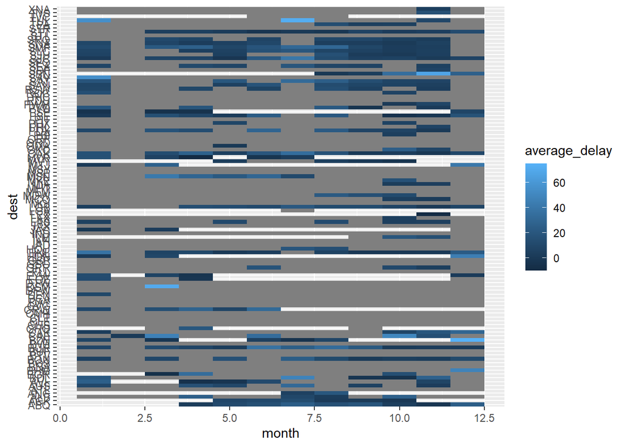

```r
ggplot(data = delay, mapping  = aes(x = month, y = dest, fill = average_delay)) +
  geom_tile()
```

# Chapter 5 (Pg. 104)

## Exercise 2

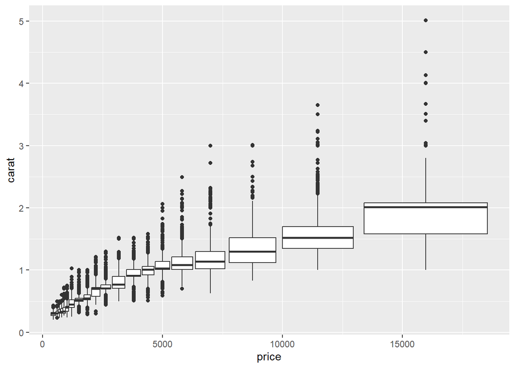

```r
ggplot(data = diamonds, mapping = aes(x = price, y = carat)) +
  geom_boxplot(mapping = aes(group = cut_number(price, 20)))
```

It appears that as diamonds get larger, the variance of the price does as well. This did surprise me, but I did expect larger diamonds to fetch a higher price, which they generally do.

## Exercise 3

I used the same code from Exercise 2 to help me answer this question.

It appears that as diamonds get larger, the variance of the price does as well. This did surprise me, but I did expect larger diamonds to fetch a higher price, which they generally do.

## Exercise 5

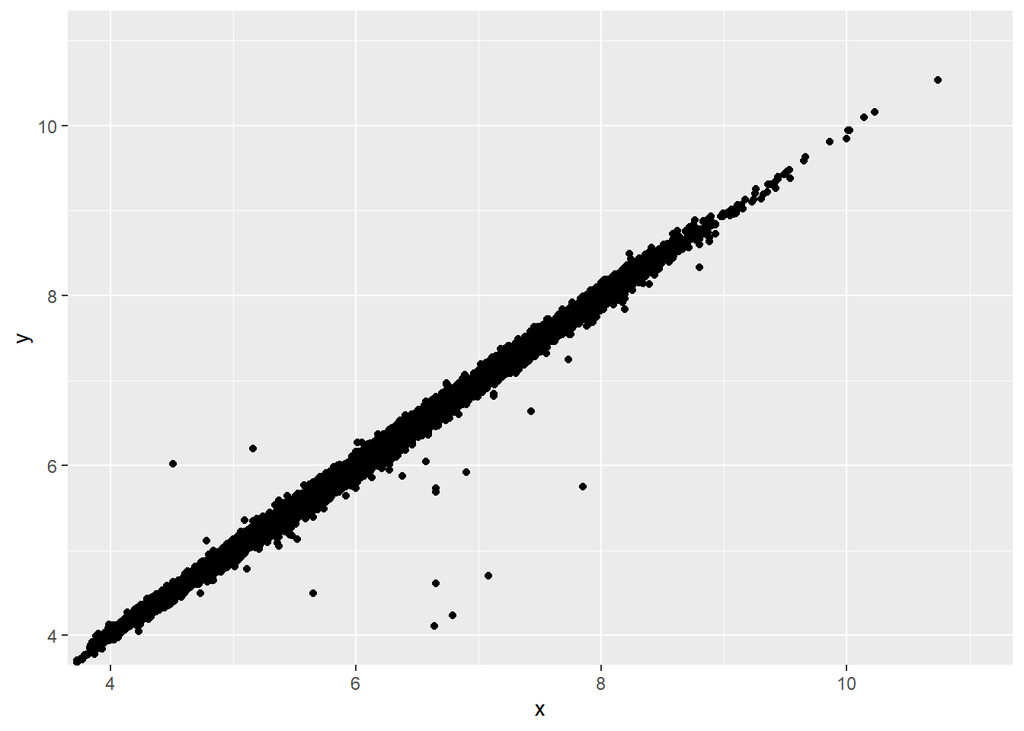

```r
ggplot(data = diamonds) +
 geom_point(mapping = aes(x = x, y = y)) +
 coord_cartesian(xlim = c(4, 11), ylim = c(4, 11))
```

A scatterplot is better than a binned plot in this display because it gives you a more realistic view of the outliers in your data. It helps when comparing the x and y values together instead of doing it separately.